# Grinding the Mocks: A Theory of Mock Drafts

Benjamin Robinson

2019-03-25

### The Nostalgia Factor

This event in April brings us both to our televisions, watching, waiting, for what might set the fortunes of our respective teams behind or ahead for the coming seasons. Now, that we’ve gotten past the nostalgia factor, let me expand into the cold-hard evidence we have about NFL team performance from season to season and the draft. Research has show that an NFL team’s record from the season before is really not as predictive of what its record will be next season as one might think (see [Lopez](http://www.sloansportsconference.com/mit_news/exploring-consistency-in-professional-sports-how-the-nfls-parity-is-somewhat-of-a-hoax/), [Kadish](http://vizual-statistix.tumblr.com/post/66117099636/edit-due-to-numerous-requests-for-the-addition), and [Puopolo](http://harvardsportsanalysis.org/2018/01/how-much-correlation-between-seasons-is-there-in-each-major-north-american-sports-league/)). This research largely attributes this phenomenon to the NFL’s short 16 game schedule that can magnify a few games difference in record from the year prior as a larger change in winning percentage than in a sport like baseball where teams play 162 games. However, I also believe that the draft, which is the primary means by which teams can acquire low-cost, high-value talent, plays a part in this equation. Hit on a couple of impact players in the draft and suddenly the fortunes of your team can begin to change!

Yet, even more [research](https://eml.berkeley.edu/~webfac/malmendier/e218_sp06/Thaler.pdf) into the draft goes to show how much of a [crapshoot](http://massey-peabody.com/wp-content/uploads/2012/08/massey-thaler-losers-curse-management-science-july-2013.pdf) it really is! Yet, despite this, a new generation of [“armchair analysts”](https://theringer.com/2018/3/15/17123714/nfl-draft-gurus-kiper-mcshay-twitter-mock-drafts) has cropped up with the proliferation of film from college games that is now available online. These analysts hope to make a judgement about the players’ skill and his draft prospects from a combination of film study, athletic measurements, and anecdotal comparisons to other players in order to project which college players will be better professionals than others. As a data obsessed person, I find this level of analysis about the draft in the face of such overwhelming odds to be a little crazy and I don’t aim to take part in it largely because I don’t have the skill for it and that is not at all where my expertise lies. Instead, my goal is provide my own theory of predicting the NFL Draft (not how good a player will be) that does not involve a single minute of film study or player comparisons. Rather, my theory benefits from the proliferation of hundreds of “armchair analysts”, media members, and football professionals across the internet that cover the NFL Draft each year to generate predictions about the NFL Draft through the creation of so-called “mock drafts”.

### The Method to the Madness

Using this crowd-sourced method allows me to calculate summary statistics for the value of players appearing in mock drafts and use historical data to make predictions with some level of statistical validity to them about the multitude of ways which the NFL Draft could play out. Starting with the 2018 NFL Draft, I collected data on hundreds of mock drafts with the goal of creating a proof of concept that I could use to make some conclusions about the value of mock draft data in answering the following questions:

- Who are the consensus top prospects at each position by average, median, and a weighted (by how close a pick is made to the day of the draft) average mock draft position metrics?
- How are draft eligible players’ stocks changing as the draft process goes on? Is a player’s stock really going up or is that just hearsay? I want to follow along the journey of a player’s stock using data to get a sense of how their stock is trending and where a player might end up getting drafted.
- How well do mock drafts do on the whole for predicting where a player might get taken in the draft? Which players were the biggest *“reaches”* and *“steals”*?
- Finally, who makes the most accurate predictions? Fans, the media, or experts? Which group’s predictions should we be following to get the best picture of the landscape of the NFL draft?

With this in mind, I built a web application ([built using R, the open source statistical computing language, and its Shiny web development framework (http://shiny.rstudio.com/)] for all you data science/tech minded folks out there) as an attempt to visualize and communicate my findings about each of these questions.

You can now use the data product that I developed to:

- Rank players across position groups by various metrics of mock draft position:

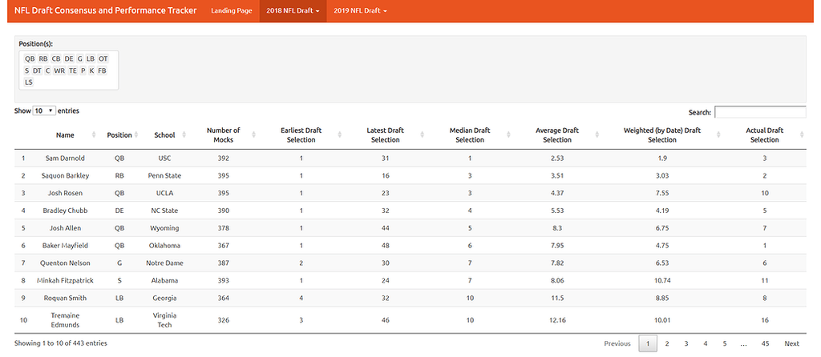

- Track a draft prospect’s stock throughout the NFL draft process:

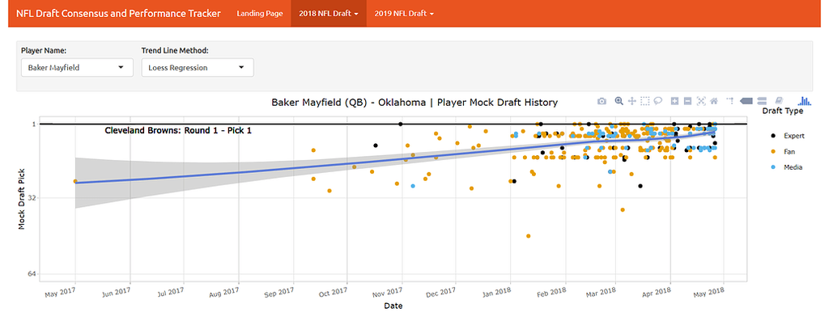

- See how accurate the mock drafts were at predicting the actual outcomes for individual players and the entire draft classes of specific NFL teams:

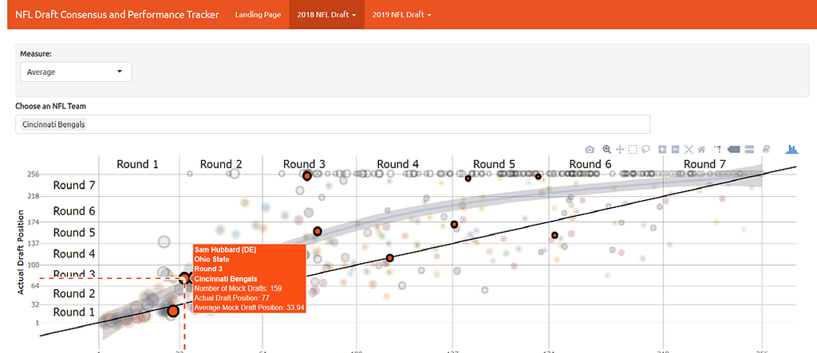

- Look at the performance of mock draft predictions across entire groups of mock draft creators:

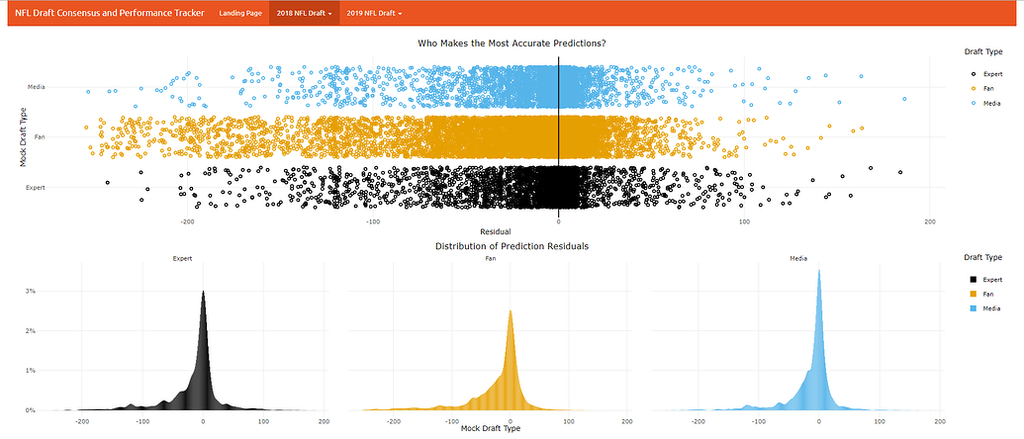

### What’s Next?

Recently, I was lucky enough to be selected to take part in my company’s leadership development training program. In addition to it being a great opportunity for my career development, it has also provided me with the space to do some self-reflection (and I swear this has to do with the draft!) about how I approach leadership. In one of our first sessions we discussed breaking down leaders into three buckets: leaders who lead with their **head**, their **heart**, and their **guts**. Each of us has a mix of each of these qualities that makes up our leadership style and as you can probably already tell from this blog post my style primarily relies on my head. However, relying too much on one of these styles can be detrimental. Famously, former NFL personnell executive Michael Lombardi has told stories about how former Oakland Raiders owner Al Davis led his team’s draft process with a huge reliance on his “gut” instinct ([see this article for plenty of anecdotes] (https://www.theringer.com/2017/4/25/16036754/al-davis-michael-lombardi-gm-street-1c323bba69ab)).

I ultimately think this is the biggest challenge of introducting analytics into any context, but especially in professional (American) football and especially the NFL Draft (which many people think is unpredictable) because of how gut-strong the people involved in these industries are. That is why I am challenging people involved with the draft to think a little more with their heads and take just as seriously what I am doing in “grinding the mocks” as so many others do in “grinding the tape” because ultimately they all go hand-in-hand in providing a larger body of evidence of how the NFL draft unfolds. This is all to say that I am looking forward to this journey and would love to have you along for the ride!

As the NFL likes to say about the draft:

[figure not shown]